# R Open Labs 3 - Data Storage Types and Factors

Chelsea Estancona

2/8/2018

```r
library(foreign)
```

Today, we’ll use our .dta (Stata) file from last week. If you don’t already have it downloaded, you can get the file from here: http://guides.lib.unc.edu/ld.php?content_id=39730747. Once the data are downloaded, make sure the file is in your working directory.

```r
My_data <- read.dta("/Users/chelseaestancona/Dropbox/Teaching/R Open Labs/all.dta")
```

### Types of data storage

It’s helpful to know how variables in our data are stored - this affects how we run analyses, make plots, and generally convey information. For this set of examples, let’s return to the My_data file from above (data about arsenic in wells).

```r
str(My_data)
```

```
## 'data.frame':    6510 obs. of  57 variables:
##  $ id          : int  1 2 3 4 5 6 7 8 9 10 ...
##  $ as          : int  236 71 207 115 196 110 141 390 297 324 ...
##  $ lsg         : int  0 1 1 0 0 0 1 0 0 0 ...
##  $ oldstat     : int  12 2 3 12 12 1 0 2 2 1 ...
##  $ func        : int  1 1 1 1 0 1 0 1 1 1 ...
##  $ rel         : int  1 1 3 1 1 2 3 1 1 1 ...
##  $ assn        : int  0 0 0 0 1 1 1 1 1 0 ...
##  $ drink       : int  0 1 1 0 23 0 1 0 0 0 ...
##  $ status      : int  0 0 0 0 0 0 2 0 0 0 ...
##  $ howknow     : int  12 12 1 12 12 1 NA 12 12 1 ...
##  $ cucard      : int  2 1 0 1 1 1 0 0 1 1 ...
##  $ survey      : int  1 1 1 1 1 1 0 1 1 1 ...
##  $ change      : Factor w/ 5 levels "no","cw","pw",..: 3 3 1 3 3 3 3 3 3 3 ...
##  $ why         : int  1 1 NA 1 0 1 1 1 1 1 ...
```

[output cut: 63 more lines]

```r
class(My_data$distnearest)
```

```
## [1] "numeric"
```

```r
is.numeric(My_data$distnearest)
```

```
## [1] TRUE
```

```r
is.character(My_data$distnearest)
```

```
## [1] FALSE
```

Because ‘distnearest’ is telling us the distance from a home to the nearest well, this makes sense that this variable would be stored as a numeric value.

However, there’s another variable: ‘switch’, which codes whether or not a family changed its source of water:

```r
head(My_data$switch)
```

```
## [1] switch   switch   noswitch switch   switch   switch
## Levels: noswitch switch
```

```r
class(My_data$switch)
```

```
## [1] "factor"
```

```r
is.numeric(My_data$switch)
```

```
## [1] FALSE
```

If we want to change a variable’s class, we can. However, there are a few things to be aware of! First, it’s always a good idea to create a new variable, meaning that we preserve both versions. Second - factors can be hard to work with!

```r
My_data$switch_2<-as.character(My_data$switch)
head(My_data$switch_2)
```

```
## [1] "switch"   "switch"   "noswitch" "switch"   "switch"   "switch"
```

```r
#Can we convert a factor() to a numeric value?
My_data$switch_3<-as.numeric(My_data$switch)
head(My_data$switch)
```

```
## [1] switch   switch   noswitch switch   switch   switch
## Levels: noswitch switch
```

```r
mean(na.omit(My_data$switch_3)) #Is this sensible?
```

```
## [1] 1.391846
```

### Working with factors

Factors are used to represent categorical data, and can be ordered or unordered.

R stores factors as integers, and assigns labels associated with these unique integers. While factors look (and often behave) like character vectors, they are actually integers under the hood, and you need to be careful when treating them like strings - they don’t function the same way!

Once created, factors can only contain a pre-defined set values, known as levels. By default, R always sorts levels in alphabetical order.

Let’s make some vectors of data to better experiment with factors.

```r
color_vec<-as.factor(c("red", "blue", "green", "yellow"))
levels(color_vec)
```

```
## [1] "blue"   "green"  "red"    "yellow"
```

```r
nlevels(color_vec)
```

```
## [1] 4
```

You might notice that our levels aren’t in any particular order. For this case of colors, it likely doesn’t matter: there isn’t a low - high spectrum.

But for other factor variables, it will - like below:

```r
dogs <- factor(c("small", "big", "medium", "small", "small", "medium", "big"))
levels(dogs)
```

```
## [1] "big"    "medium" "small"
```

R’s storage of factors isn’t always in the order we would expect. In this case, it’s meaningful for our factor to be ordered. Let’s investigate doing so in a few ways.

```r
dogs <- factor(dogs, levels = c("small", "medium", "big")) #we can respecify the levels with factor()
levels(dogs)
```

```
## [1] "small"  "medium" "big"
```

```r
min(dogs) #but, we still can't find the 'lowest' category
```

```
## Error in Summary.factor(structure(c(1L, 3L, 2L, 1L, 1L, 2L, 3L), .Label = c("small", : 'min' not meaningful for factors
```

```r
dogs <- factor(dogs, levels = c("small", "medium", "big"), ordered=TRUE) #changes R's internal definition of levels
levels(dogs)
```

```
## [1] "small"  "medium" "big"
```

```r
min(dogs) #now R recognizes a distinct order
```

```
## [1] small
## Levels: small < medium < big
```

Using ‘ordered’ for these labels can be useful when we have factor variables with names. What about when we want to make numbers into factors?

```r
f <- factor(c(3.4, 1.2, 5))
as.numeric(f)
```

```
## [1] 2 1 3
```

Whoa! These really don’t resemble the three numbers above. Instead, we have to take an additional step. We can index the factor with its underlying integer values (how R saves the factor) - and then convert it successfully to a numeric vector.

```r
f_2 <- levels(f)[f]
f_2
```

```
## [1] "3.4" "1.2" "5"
```

```r
as.numeric(f_2)
```

```
## [1] 3.4 1.2 5.0
```

Often, our data will appear to be numeric, (like the f vector below) but are actually factors. Take care when renaming and using these variables!

Lastly, we might want to combine or remove levels of a factor variable. Let’s imagine that we’re only interested in whether or not a dog is ‘big’ or ‘small’ from above, so we’re going to combine medium with small.

```r
dogs[dogs == 'medium'] <- 'small'
dogs
```

```
## [1] small big   small small small small big
## Levels: small < medium < big
```

But R still thinks there’s a possible ‘medium’ level. So, we have to update R that there’s now only two levels available:

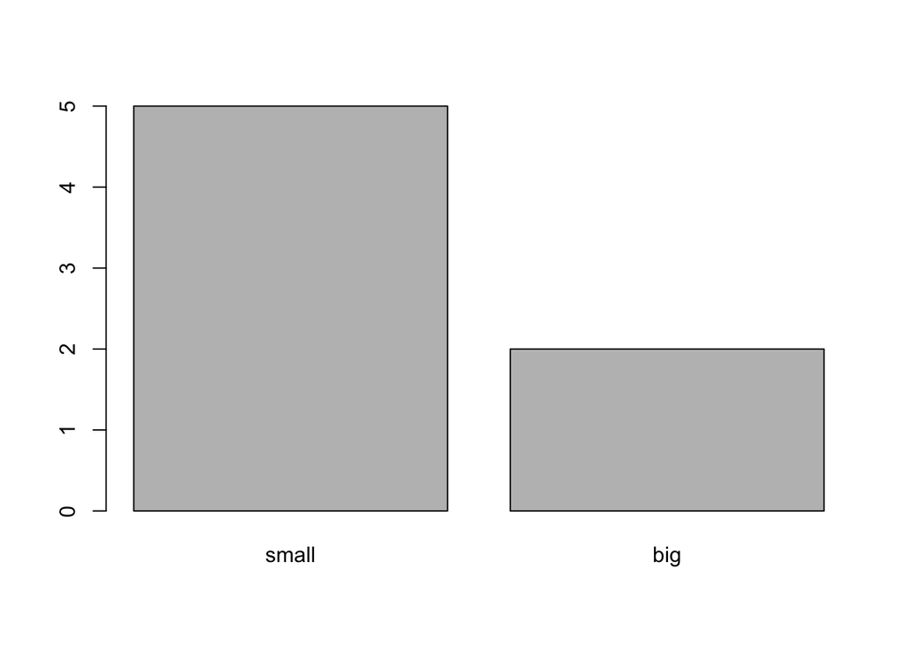

```r
dogs <- droplevels(dogs)
plot(dogs)
```

### Exercise 1:

Investigate how several variables in a dataset you’ve imported (possibly your data from last week? Or My_data, above). Change a numeric variable to a character.

### Exercise 2:

Using the built-in R data ‘iris’ (can be brought into your global environment as below), find the levels of the ‘Species’ variable. Reorder them.

Reclassify the ‘Sepal.Length’ variable as a factor. Investigate what happens when you change it back to numeric. How would you avoid this?

Combine two of the Iris species. Drop the remaining level. Use plot() as above to produce a basic barplot.

```r
data(iris)
```